# Recommendations with IBM

In this notebook, I will be putting my recommendation skills to use on real data from the IBM Watson Studio platform.

By following the table of contents, I will build out a number of different methods for making recommendations that can be used for different situations.

I. Exploratory Data Analysis  
II. Rank Based Recommendations  
III. User-User Based Collaborative Filtering  
V. Matrix Factorization

```python
import pandas as pd
import numpy as np
import matplotlib.pyplot as plt
import pickle

%matplotlib inline

df = pd.read_csv('data/user-item-interactions.csv')
df_content = pd.read_csv('data/articles_community.csv')
del df['Unnamed: 0']
del df_content['Unnamed: 0']

# Show df to get an idea of the data
df.head()
```

|  | article_id | title | email |
| --- | --- | --- | --- |
| 0 | 1430.0 | using pixiedust for fast, flexible, and easier... | ef5f11f77ba020cd36e1105a00ab868bbdbf7fe7 |
| 1 | 1314.0 | healthcare python streaming application demo | 083cbdfa93c8444beaa4c5f5e0f5f9198e4f9e0b |
| 2 | 1429.0 | use deep learning for image classification | b96a4f2e92d8572034b1e9b28f9ac673765cd074 |
| 3 | 1338.0 | ml optimization using cognitive assistant | 06485706b34a5c9bf2a0ecdac41daf7e7654ceb7 |
| 4 | 1276.0 | deploy your python model as a restful api | f01220c46fc92c6e6b161b1849de11faacd7ccb2 |

```python
# Show df_content to get an idea of the data
df_content.head()
```

|  | doc_body | doc_description | doc_full_name | doc_status | article_id |
| --- | --- | --- | --- | --- | --- |
| 0 | Skip navigation Sign in SearchLoading...\r\n\r... | Detect bad readings in real time using Python ... | Detect Malfunctioning IoT Sensors with Streami... | Live | 0 |
| 1 | No Free Hunch Navigation * kaggle.com\r\n\r\n ... | See the forest, see the trees. Here lies the c... | Communicating data science: A guide to present... | Live | 1 |
| 2 | ☰ * Login\r\n * Sign Up\r\n\r\n * Learning Pat... | Here’s this week’s news in Data Science and Bi... | This Week in Data Science (April 18, 2017) | Live | 2 |
| 3 | DATALAYER: HIGH THROUGHPUT, LOW LATENCY AT SCA... | Learn how distributed DBs solve the problem of... | DataLayer Conference: Boost the performance of... | Live | 3 |
| 4 | Skip navigation Sign in SearchLoading...\r\n\r... | This video demonstrates the power of IBM DataS... | Analyze NY Restaurant data using Spark in DSX | Live | 4 |

### Part I : Exploratory Data Analysis

`1.` What is the distribution of how many articles a user interacts with in the dataset?

```python
#how many articles a user interacts with in the datase
article_count = df.groupby('email').count()[['article_id']].reset_index()
article_count.head()
```

|  | email | article_id |
| --- | --- | --- |
| 0 | 0000b6387a0366322d7fbfc6434af145adf7fed1 | 13 |
| 1 | 001055fc0bb67f71e8fa17002342b256a30254cd | 4 |
| 2 | 00148e4911c7e04eeff8def7bbbdaf1c59c2c621 | 3 |
| 3 | 001a852ecbd6cc12ab77a785efa137b2646505fe | 6 |
| 4 | 001fc95b90da5c3cb12c501d201a915e4f093290 | 2 |

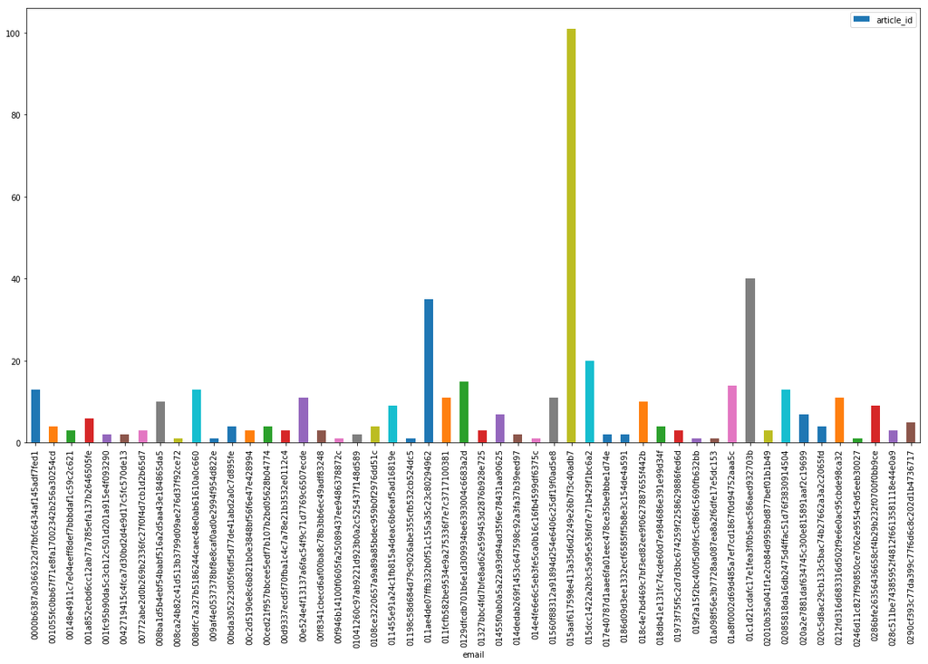

```python
article_count.head(50).plot(kind='bar' ,x='email', y='article_id', figsize=(20,10))
```

```python
article_count.describe()
```

|  | article_id |
| --- | --- |
| count | 5148.000000 |
| mean | 8.930847 |
| std | 16.802267 |
| min | 1.000000 |
| 25% | 1.000000 |
| 50% | 3.000000 |
| 75% | 9.000000 |
| max | 364.000000 |

`2.` Explore and remove duplicate articles from the **df_content** dataframe.

```python
# Find and explore duplicate articles
duplicate_article = df_content.duplicated(['article_id']).sum()
duplicate_article
```

```
5
```

```python
# Remove any rows that have the same article_id - only keep the first
df_content.drop_duplicates(['article_id'] , keep='first',inplace=True)
```

```python
#check
duplicate_article = df_content.duplicated(['article_id']).sum()
duplicate_article
```

```
0
```

`3.` I will use the cells below to find:

**a.** The number of unique articles that have an interaction with a user.  
**b.** The number of unique articles in the dataset (whether they have any interactions or not).  
**c.** The number of unique users in the dataset. (excluding null values)  
**d.** The number of user-article interactions in the dataset.

```python
#a
df.article_id.nunique()
```

```
714
```

```python
#b
df_content.doc_full_name.nunique()
```

```
1051
```

```python
#c
df.email.nunique()
```

```
5148
```

```python
#d
df.shape[0]
```

```
45993
```

`4.` I will use the cells below to find the most viewed **article_id**, as well as how often it was viewed. After talking to the company leaders, the `email_mapper` function was deemed a reasonable way to map users to ids. There were a small number of null values, and it was found that all of these null values likely belonged to a single user (which is how they are stored using the function below).

```python
df.groupby('article_id').count()['email'].sort_values(ascending=False).head(1)
```

```
article_id
1429.0    937
Name: email, dtype: int64
```

```python
most_viewed_article_id = '1429.0' # The most viewed article in the dataset as a string with one value following the decimal
max_views = 937 # The most viewed article in the dataset was viewed how many times?
```

```python
#map the user email to a user_id column and remove the email column

def email_mapper():
    coded_dict = dict()
    cter = 1
    email_encoded = []

    for val in df['email']:
        if val not in coded_dict:
            coded_dict[val] = cter
            cter+=1

        email_encoded.append(coded_dict[val])
    return email_encoded

email_encoded = email_mapper()
del df['email']
df['user_id'] = email_encoded

# show header
df.head()
```

|  | article_id | title | user_id |
| --- | --- | --- | --- |
| 0 | 1430.0 | using pixiedust for fast, flexible, and easier... | 1 |
| 1 | 1314.0 | healthcare python streaming application demo | 2 |
| 2 | 1429.0 | use deep learning for image classification | 3 |
| 3 | 1338.0 | ml optimization using cognitive assistant | 4 |
| 4 | 1276.0 | deploy your python model as a restful api | 5 |

### Part II: Rank-Based Recommendations

`1.` I will write a function that returns the **n** top articles ordered with most interactions as the top.

```python
def get_top_articles(n, df=df):
    '''
    INPUT:
    n - (int) the number of top articles to return
    df - (pandas dataframe) df as defined at the top of the notebook

    OUTPUT:
    top_articles - (list) A list of the top 'n' article titles

    '''
    top_ids = df.groupby('article_id').count()[['user_id']].sort_values(by=['user_id'] ,ascending=False).reset_index().head(n)
    list_ids = list(top_ids['article_id'])
    top_titles = df['article_id'].isin(list_ids)
    top_articles= list(set(df.loc[top_titles]['title']))

    return top_articles # Return the top article titles from df (not df_content)

def get_top_article_ids(n, df=df):
    '''
    INPUT:
    n - (int) the number of top articles to return
    df - (pandas dataframe) df as defined at the top of the notebook

    OUTPUT:
    top_articles - (list) A list of the top 'n' article titles

    '''
    top_articles = df.groupby('article_id').count()[['user_id']].sort_values(by=['user_id'] ,ascending=False).reset_index().head(n)
    top_articles = list(top_articles['article_id'])

    return top_articles # Return the top article ids
```

```python
print(get_top_articles(10))
print(get_top_article_ids(10))
```

[output not shown]

### Part III: User-User Based Collaborative Filtering

`1.`The function below to reformat the **df** dataframe to be shaped with users as the rows and articles as the columns.

- Each **user** should only appear in each **row** once.
- Each **article** should only show up in one **column**.
- **If a user has interacted with an article, then place a 1 where the user-row meets for that article-column**. It does not matter how many times a user has interacted with the article, all entries where a user has interacted with an article should be a 1.
- **If a user has not interacted with an item, then place a zero where the user-row meets for that article-column**.

```python
# create the user-article matrix with 1's and 0's

def create_user_item_matrix(df):
    '''
    INPUT:
    df - pandas dataframe with article_id, title, user_id columns

    OUTPUT:
    user_item - user item matrix

    Description:
    Return a matrix with user ids as rows and article ids on the columns with 1 values where a user interacted with
    an article and a 0 otherwise
    '''

    #user-item matrix and fill NaN with zeros
    user_item = df.groupby(['user_id', 'article_id'])['title'].max().unstack().fillna(0)

    # 1 if interact else 0
    for i in user_item:
        user_item[i] = user_item[i].apply(lambda x: 1 if x != 0 else 0 )

    return user_item # return the user_item matrix

user_item = create_user_item_matrix(df)
```

`2.` The function below will take a user_id and provide an ordered list of the most similar users to that user (from most similar to least similar). The returned result should not contain the provided user_id, as we know that each user is similar to him/herself. Because the results for each user here are binary, it (perhaps) makes sense to compute similarity as the dot product of two users.

```python
def find_similar_users(user_id, user_item=user_item):
    '''
    INPUT:
    user_id - (int) a user_id
    user_item - (pandas dataframe) matrix of users by articles:
                1's when a user has interacted with an article, 0 otherwise

    OUTPUT:
    similar_users - (list) an ordered list where the closest users (largest dot product users)
                    are listed first

    Description:
    Computes the similarity of every pair of users based on the dot product
    Returns an ordered

    '''
    # compute similarity of each user to the provided user
    similarity = user_item.dot(user_item.loc[user_id])
    # sort by similarity
    most_similar_users = similarity.sort_values(ascending= False)
    # create list of just the ids
    most_similar_users = most_similar_users.index
    # remove the own user's id
    most_similar_users = most_similar_users.drop(user_id)

    return most_similar_users # return a list of the users in order from most to least similar
```

```python
# Do a spot check of your function
print("The 10 most similar users to user 1 are: {}".format(find_similar_users(1)[:10]))
print("The 5 most similar users to user 3933 are: {}".format(find_similar_users(3933)[:5]))
print("The 3 most similar users to user 46 are: {}".format(find_similar_users(46)[:3]))
```

```
The 10 most similar users to user 1 are: Int64Index([3933, 23, 3782, 203, 4459, 131, 3870, 46, 4201, 5041], dtype='int64', name='user_id')
The 5 most similar users to user 3933 are: Int64Index([1, 23, 3782, 4459, 203], dtype='int64', name='user_id')
The 3 most similar users to user 46 are: Int64Index([4201, 23, 3782], dtype='int64', name='user_id')
```

`3.` Now that we have a function that provides the most similar users to each user, I will want to use these users to find articles you can recommend. The functions below returnS the articles we would recommend to each user.

```python
def get_article_names(article_ids, df=df):
    '''
    INPUT:
    article_ids - (list) a list of article ids
    df - (pandas dataframe) df as defined at the top of the notebook

    OUTPUT:
    article_names - (list) a list of article names associated with the list of article ids
                    (this is identified by the title column)
    '''
    articles = df['article_id'].isin(article_ids)
    articles = df.loc[articles]
    article_names = set(articles['title'])
    article_names = list(article_names)

    return article_names # Return the article names associated with list of article ids


def get_user_articles(user_id, user_item=user_item):
    '''
    INPUT:
    user_id - (int) a user id
    user_item - (pandas dataframe) matrix of users by articles:
                1's when a user has interacted with an article, 0 otherwise

    OUTPUT:
    article_ids - (list) a list of the article ids seen by the user
    article_names - (list) a list of article names associated with the list of article ids
                    (this is identified by the doc_full_name column in df_content)

    Description:
    Provides a list of the article_ids and article titles that have been seen by a user
    '''
    # get the user
    user =user_item.loc[user_id]
    # get seen articles' ids
    art_ids = []
    for arti_id , value in user.iteritems():
        if value == 1:
            art_ids.append(arti_id)

    # get articles full name
    seen_articles = df['article_id'].isin(art_ids)
    article_names = set(df[seen_articles]['title'])
    article_names = list(article_names)
    article_ids = [str(i) for i in art_ids]

    return article_ids, article_names # return the ids and names


def user_user_recs(user_id, m=10):
    '''
    INPUT:
    user_id - (int) a user id
    m - (int) the number of recommendations you want for the user

    OUTPUT:
    recs - (list) a list of recommendations for the user

    Description:
    Loops through the users based on closeness to the input user_id
    For each user - finds articles the user hasn't seen before and provides them as recs
    Does this until m recommendations are found

    Notes:
    Users who are the same closeness are chosen arbitrarily as the 'next' user

    For the user where the number of recommended articles starts below m
    and ends exceeding m, the last items are chosen arbitrarily

    '''
    # get articles names and ids seen by the user
    articles_seen_ids , articles_seen_names = get_user_articles(user_id)
    articles_seen_ids = set(articles_seen_ids)
    articles_seen_names = set(articles_seen_names)
    #get similar users
    most_similar_users = find_similar_users(user_id)

    recs = []

    #get articles seen by each user
    for user in most_similar_users:
        # check recommendation number
        if len(recs) < m :
            #only get the articles ids
            user_seen_ids = set(get_user_articles(user, user_item)[0])
            #get the articles that not seen by the user
            recommended_ids = user_seen_ids.difference(articles_seen_ids)
            #bc list start from 0 index
            req_recs = m - len(recs)
            # to keep only 10
            recommended_ids = list(recommended_ids)[:req_recs]
            #add
            recs.extend(recommended_ids)
            articles_seen_ids = articles_seen_ids.union(recommended_ids)


    return recs # return your recommendations for this user_id
```

```python
# #just notes for me

# Before adding to the recs array, you should have checked how many more recommendations were required and add only
# those many recommendations to the array. You need an additional check because there can be many article recommendations
# that can be derived from the next user.
# e.g. we need 10 recommendations and if we already have 7 recommendations created and the next similar user gives us 5 new
# recommendations, we will get a total of 12 recommendations instead of the required 10 without the additional check. So,
# if we perform the check of how many more recommendations are required,
# we can return the top 3 recommendations from the next user to get a total of 10 recommendations
```

```python
# Check Results
get_article_names(user_user_recs(1, 10)) # Return 10 recommendations for user 1
```

```
['1448    i ranked every intro to data science course on...\nName: title, dtype: object',
 'recent trends in recommender systems',
 'model bike sharing data with spss',
 'discover hidden facebook usage insights',
 'insights from new york car accident reports',
 'use sql with data in hadoop python',
 'working with db2 warehouse on cloud in data science experience',
 'data tidying in data science experience',
 'higher-order logistic regression for large datasets',
 'pixieapp for outlier detection']
```

```python
similarity = user_item.dot(user_item.loc[1])
df2 = pd.DataFrame(similarity, columns=['similarity']).reset_index()
df2['num_interactions'] = df.groupby('user_id').count()[['article_id']]['article_id']
df2.head(2)
```

|  | user_id | similarity | num_interactions |
| --- | --- | --- | --- |
| 0 | 1 | 36 | NaN |
| 1 | 2 | 2 | 47.0 |

```python
us = df2['user_id'] == 1
us[us].index[0]
```

```
0
```

```python
df2.drop(index= us[us].index[0] , inplace=True )
```

```python
df2.head(2)
```

|  | user_id | similarity | num_interactions |
| --- | --- | --- | --- |
| 1 | 2 | 2 | 47.0 |
| 2 | 3 | 6 | 6.0 |

```python
df2.isnull().sum()
```

```
user_id             0
similarity          0
num_interactions    0
dtype: int64
```

```python
def get_top_sorted_users(user_id, df=df, user_item=user_item):
    '''
    INPUT:
    user_id - (int)
    df - (pandas dataframe) df as defined at the top of the notebook
    user_item - (pandas dataframe) matrix of users by articles:
            1's when a user has interacted with an article, 0 otherwise


    OUTPUT:
    neighbors_df - (pandas dataframe) a dataframe with:
                    neighbor_id - is a neighbor user_id
                    similarity - measure of the similarity of each user to the provided user_id
                    num_interactions - the number of articles viewed by the user - if a u

    Other Details - sort the neighbors_df by the similarity and then by number of interactions where
                    highest of each is higher in the dataframe

    '''
    #creat neighbors dataframe with user id , similarity and  num_interactions
    similarity = user_item.dot(user_item.loc[user_id])
    neighbors_df = pd.DataFrame(similarity, columns=['similarity']).reset_index()
    neighbors_df['num_interactions'] = df.groupby('user_id').count()[['article_id']]['article_id']
    #sort
    neighbors_df = neighbors_df.sort_values(by=['similarity', 'num_interactions'], ascending=False)
    #remove the given user id
    user = neighbors_df['user_id'] == user_id
    neighbors_df.drop(index= user[user].index[0] , inplace=True )

    return neighbors_df # Return the dataframe specified in the doc_string


def user_user_recs_part2(user_id, m=10):
    '''
    INPUT:
    user_id - (int) a user id
    m - (int) the number of recommendations you want for the user

    OUTPUT:
    recs - (list) a list of recommendations for the user by article id
    rec_names - (list) a list of recommendations for the user by article title

    Description:
    Loops through the users based on closeness to the input user_id
    For each user - finds articles the user hasn't seen before and provides them as recs
    Does this until m recommendations are found

    Notes:
    * Choose the users that have the most total article interactions
    before choosing those with fewer article interactions.

    * Choose articles with the articles with the most total interactions
    before choosing those with fewer total interactions.

    '''
    # get articles names and ids seen by the user
    articles_seen_ids , articles_seen_names = get_user_articles(user_id)
    articles_seen_ids = set(articles_seen_ids)
    articles_seen_names = set(articles_seen_names)
    #get similar users
    most_similar_users = find_similar_users(user_id)
#     users_ids = list(most_similar_users['user_id'])

    recs = []
    rec_names = []

    #get articles seen by each user
    for user in most_similar_users:
        if len(recs) <m:
            #get users seen articles and names
            user_seen_ids , user_seen_names = get_user_articles(user)
            user_seen_ids = set(user_seen_ids)
            user_seen_names = set(user_seen_names)

            #articles ids that not seen by the user
            new_recs = user_seen_ids.difference(articles_seen_ids)
            #index bc list start from 0
            req_recs_ids = m - len(recs)
            new_recs = list(new_recs)[:req_recs_ids]
            #add
            recs.extend(new_recs)
            articles_seen_ids = articles_seen_ids.union(new_recs)

            #articles names that not seen by the user
            new_rec_names =user_seen_names.difference(articles_seen_names)
            #index bc list start from 0
            req_recs_names = m - len(rec_names)
            new_rec_names = list(new_rec_names)[:req_recs_names]
            rec_names.extend(new_rec_names)
            articles_seen_names = articles_seen_names.union(new_rec_names)

    return recs, rec_names
```

```python
# Quick spot check
rec_ids, rec_names = user_user_recs_part2(20, 10)
print("The top 10 recommendations for user 20 are the following article ids:")
print(rec_ids)
print()
print("The top 10 recommendations for user 20 are the following article names:")
print(rec_names)
```

[output not shown]

```python
most_similar_users = get_top_sorted_users(1)
most_similar_users.head(1)
```

|  | user_id | similarity | num_interactions |
| --- | --- | --- | --- |
| 3932 | 3933 | 35 | 5.0 |

```python
most_similar_users = get_top_sorted_users(131)
most_similar_users.head(10).tail(1)
```

|  | user_id | similarity | num_interactions |
| --- | --- | --- | --- |
| 241 | 242 | 25 | 26.0 |

`7.` By using existing functions, we can provide the top 10 recommended articles we would provide for the a new user below.

```python
new_user = '0.0'

# What would your recommendations be for this new user '0.0'?  As a new user, they have no observed articles.
# Provide a list of the top 10 article ids you would give to
top_articles_ids = get_top_article_ids(10)
new_user_recs = [str(i) for i in top_articles_ids]
```